# Datenvisualisierung 2

- Gesamten Code zeigen
- Gesamten Code verbergen
- Quellcode anzeigen

Darstellung der zusammenfassenden Statistik

Autor:in

Zugehörigkeit

Daniela Palleschi

Humboldt-Universität zu Berlin

Veröffentlichungsdatum

19. Juni 2023

# Wiederholung

Letzte Woche haben wir…

- Maße der zentralen Tendenz (neu) kennengelernt ✅
- Maße der Streuungsmaßen kennengelernt ✅
- gelernt, wie man die Funktion `summarise()` von `dplyr` benutzt ✅
- gelernt, wie man Zusammenfassungen nach (`.by =`) Gruppen erstellt ✅

# Heutige Ziele

This week we will learn how to…

- use `facet_wrap()` to plot more than three variables
- visualise summary statistics
- create multi-part plots

## 0.1 Lust auf mehr?

- Section 2.5 ([Visualising relationsips](https://r4ds.hadley.nz/data-visualize.html#visualizing-relationships)) in Wickham et al. (o. J.)
- Ch. 4 ([Representing summary statistics](https://psyteachr.github.io/introdataviz/representing-summary-statistics.html)) in Nordmann et al. (2022)

# 1 Einrichtung

```r
pacman::p_load(tidyverse,
               here,
               palmerpenguins,
               ggthemes,
               patchwork)
```

```r
df_penguins <- palmerpenguins::penguins %>%
  drop_na()
```

# 2 Review: Visualising distributions

- we did this in week 3 using
  - histograms (1 numerical variable)
  - density plots (1 numerical variable)
  - scatterplots (2 numerical variables)
  - barplots (categorical variables)
- how many variables are represented in each figure in Abbildung 1?
  - what *types* of variables are represented in each plot type?

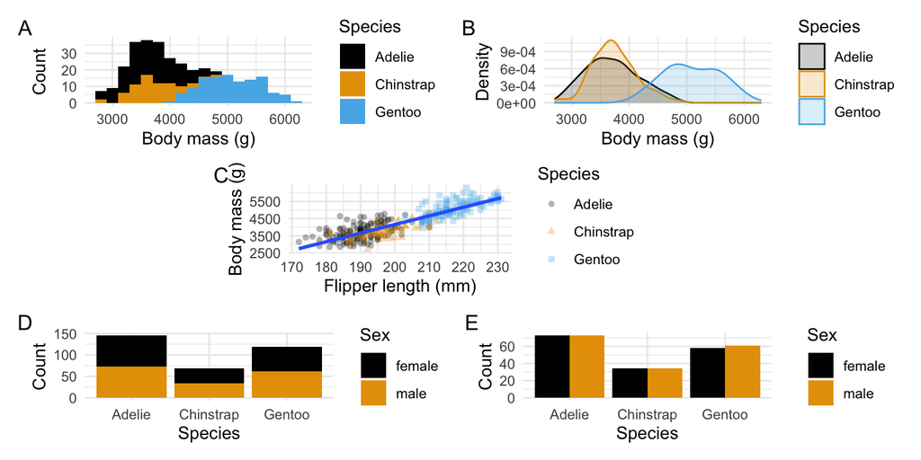

Abbildung 1: Different plots types to visualise distribution of raw data: histogram (A), density plot (B), scatterplot (C), stacked barplot (D), and dodged barplot (E)

## 2.1 Violin plots

- we can also use violin plots, which are pretty trendy at the moment
  - basically a double-sided/mirrored density plot
- violin plots are considered easier to read
  - as we’ll see later, they’re easy to layer with other plots too

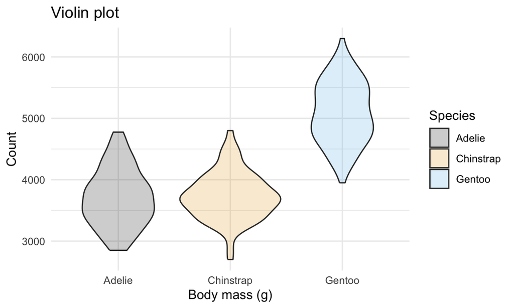

Abbildung 2: Violin plot: a mirrored density plot

```r
  df_penguins %>%
  ggplot(aes(x = species, y = body_mass_g, fill = species)) +
  geom_violin(alpha = .2) +
  labs(title = "Violin plot",
       x = "Body mass (g)",
       y = "Count",
    fill = "Species") +
  scale_color_colorblind() +
  scale_fill_colorblind() +
  theme_minimal()
```

**‘Mirrored’ density plot**

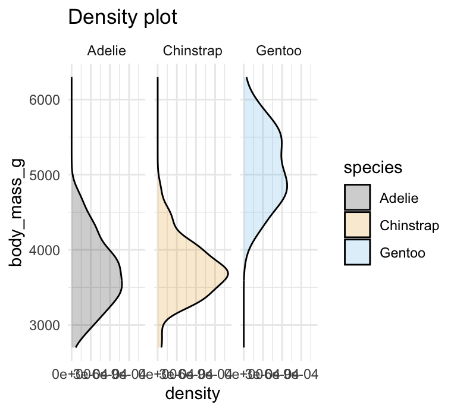

Abbildung 3: Density plot: same violin plot

```r
  df_penguins %>%
  ggplot(aes(y = body_mass_g, fill = species)) +
  facet_grid(~species) +
  geom_density(alpha = .2) +
  labs(title = "Density plot"
       ) +
  scale_color_colorblind() +
  scale_fill_colorblind() +
  theme_minimal()
```

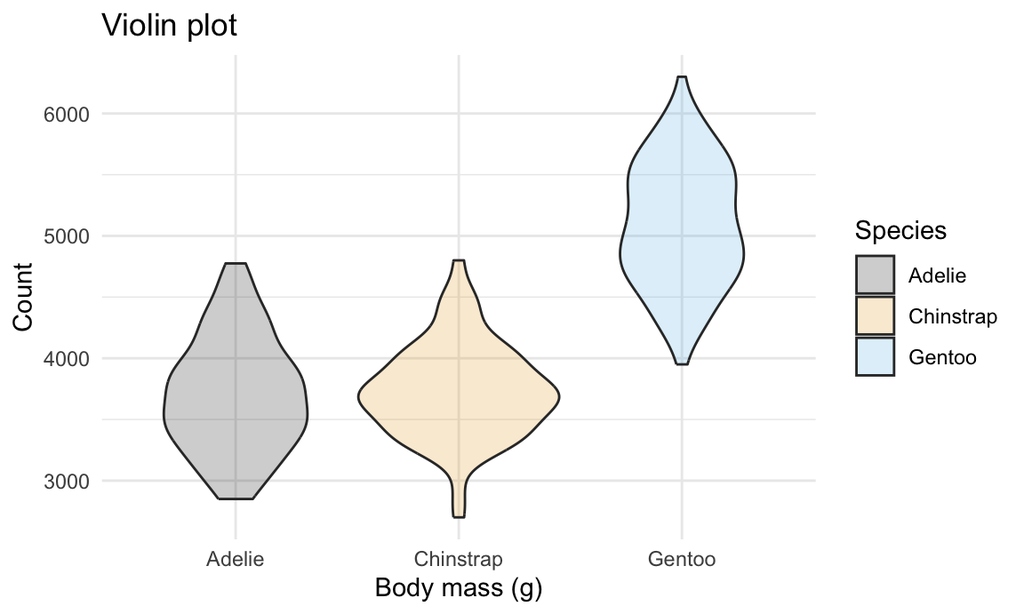

Abbildung 4: Violin plot: a mirrored density plot

```r
  df_penguins %>%
  ggplot(aes(x = species, y = body_mass_g, fill = species)) +
  geom_violin(alpha = .2) +
  labs(title = "Violin plot",
       x = "Body mass (g)",
       y = "Count",
    fill = "Species") +
  scale_color_colorblind() +
  scale_fill_colorblind() +
  theme_minimal()
```

# 3 Visualising 3 or more variables

- as we know, we can incorporate more variables by mapping them onto aesthetics (e.g., `colour`, `fill`, or `shape`)
- Abbildung 1 did this by using `colour` (all plots) and `shape` (scatterplot) to visualise `species` or `sex` in addition to what was mapped along the x- and y-axes
- adding too many variables into a single plot can make it diffcult to read
- for example, how many variables are mapped in the following code?

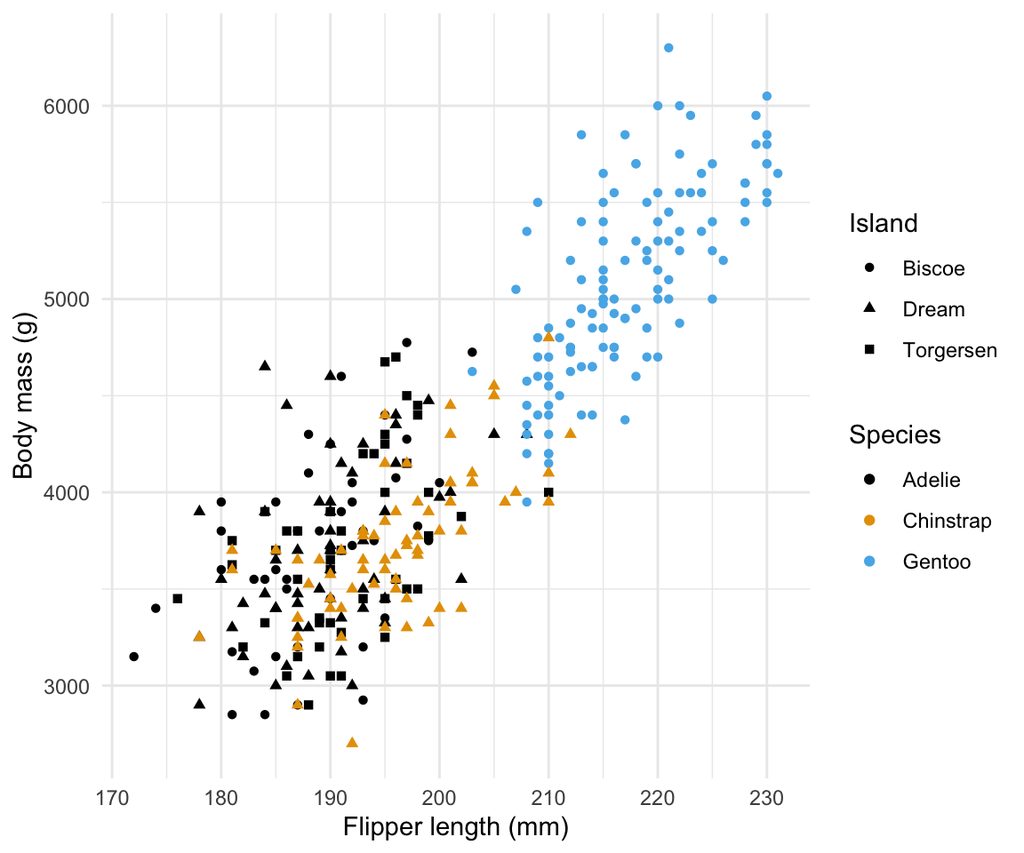

Abbildung 5: A cluttered scatterplot with 4 variables

```r
df_penguins %>%
  ggplot(aes(x = flipper_length_mm, y = body_mass_g)) +
  geom_point(aes(color = species, shape = island)) +
  labs(
    x = "Flipper length (mm)",
    y = "Body mass (g)",
    color = "Species",
    shape = "Island"
  ) +
  scale_color_colorblind() +
  theme_minimal()
```

- four: `flipper_length_mm` (x-axis), `body_mass_g` (y-axis), `species` (color), `island` (shape)
- this is a bit visually cluttered!

## 3.1 `facet_wrap()`

- a nice way to split our data into different plots is by using the `facet_wrap()`
  - can be used to split one cluttered plot into separate panels based on a categorical variable
- let’s try using `facet_wrap()` to divide Abbildung 5 into three panels, by `island`

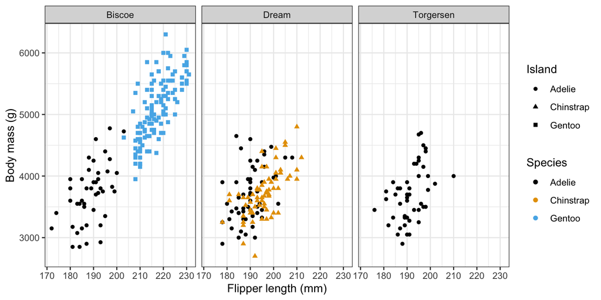

Abbildung 6: A cluttered scatterplot with 4 variables

```r
df_penguins %>%
  ggplot(aes(x = flipper_length_mm, y = body_mass_g)) +
  facet_wrap(~island) +
  geom_point(aes(color = species, shape = species)) +
  labs(
    x = "Flipper length (mm)",
    y = "Body mass (g)",
    color = "Species",
    shape = "Island"
  ) +
  scale_color_colorblind() +
  theme_bw()
```

- what type of variables can `facet_wrap()` take as its argument(s)?
  - categorical! Each ‘category’ gets its own panel

**`facet_grid()`**

`facet_wrap()` is related to `facet_grid()`, which can take two categorical variables, one in columns and one in rows. The argument for `facet_grid()` is an equation: `row~column`. So, if we add `facet_grid(sex~island)` to our plot, we should see the data in plots grouped by `sex` in rows (one row for `female`, one row for `male`) and `island` in columns (one column for each `island`)

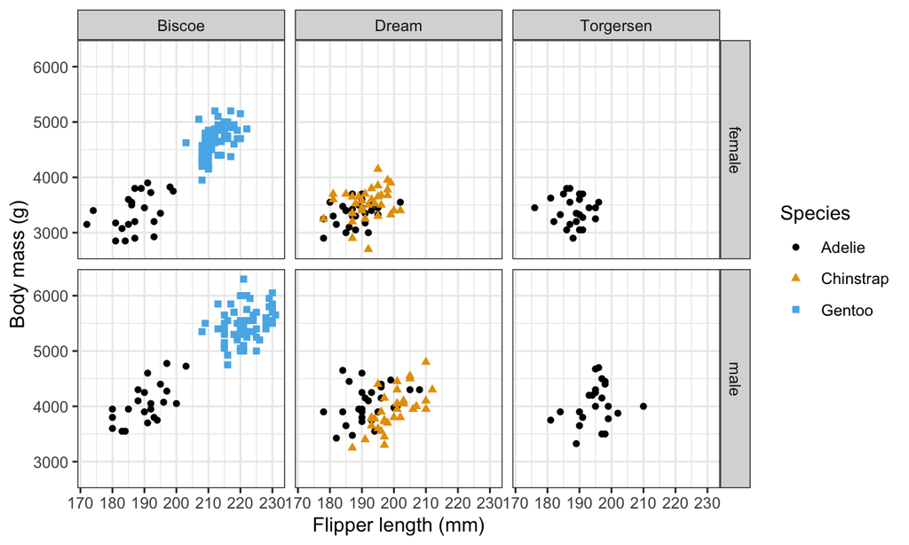

```r
df_penguins %>%
  ggplot(aes(x = flipper_length_mm, y = body_mass_g)) +
  facet_grid(sex~island) +
  geom_point(aes(color = species, shape = species)) +
  labs(
    x = "Flipper length (mm)",
    y = "Body mass (g)",
    color = "Species",
    shape = "Species"
  ) +
  scale_color_colorblind() +
  theme_bw()
```

# 4 Representing summary statistics

- last week we talked about summary statistics
  - measures of central tendency and measures of dispersion
- now we will learn how to visualise some of these statistics
  - and learn some new ones

## 4.1 Boxplot

- boxplots (sometimes called box-and-whisker plots) contain:
  - a **box** with a **line in the middle**
  - **lines sticking out** of the top and bottom of the box (the whiskers)
- which represent:
  - **thick line**: the median, also called Q2 (2nd quartile; the middle value above/below which 50% of the data lie)
  - **box**: the interquartile range (IQR; the range of values between the middle 50% of the data lie), with the boundaries:
    - Q1 (1st quartile, below which 25% of the data lie)
    - Q3 (3rd quartile, above which 25% of the data lie)
  - **whiskers**: 1.5*IQR from Q1 (lower whisker) or Q3 (upper whisker)
  - **dots**: outliers (outside the IQR)

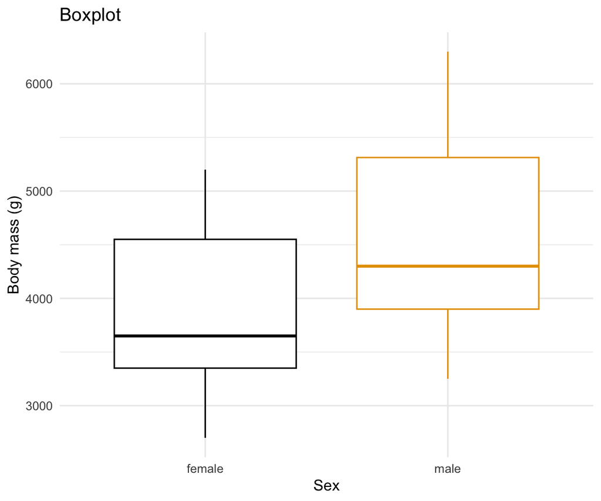

Abbildung 8: Boxplot of `df_penguins` (body mass by sex)

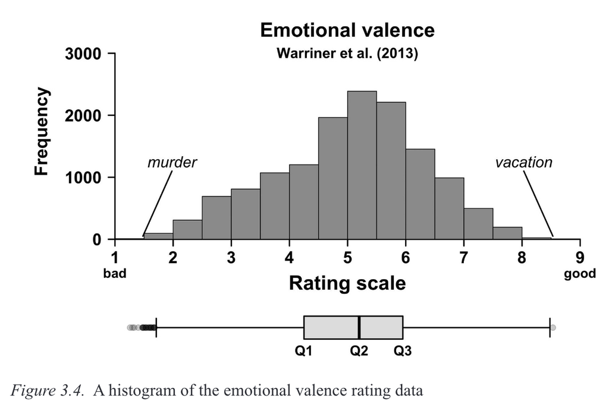

Or, explained another way:

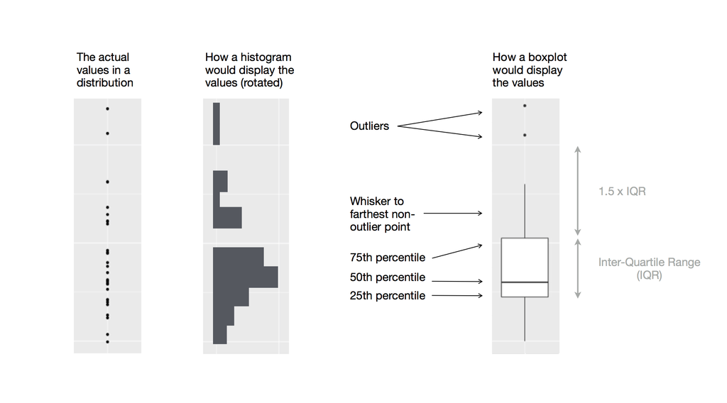

Image source: Wickham et al. (o. J.) (all rights reserved)

### 4.1.1 `geom_boxplot()`

- we can produce boxplots with `geom_boxplot()`

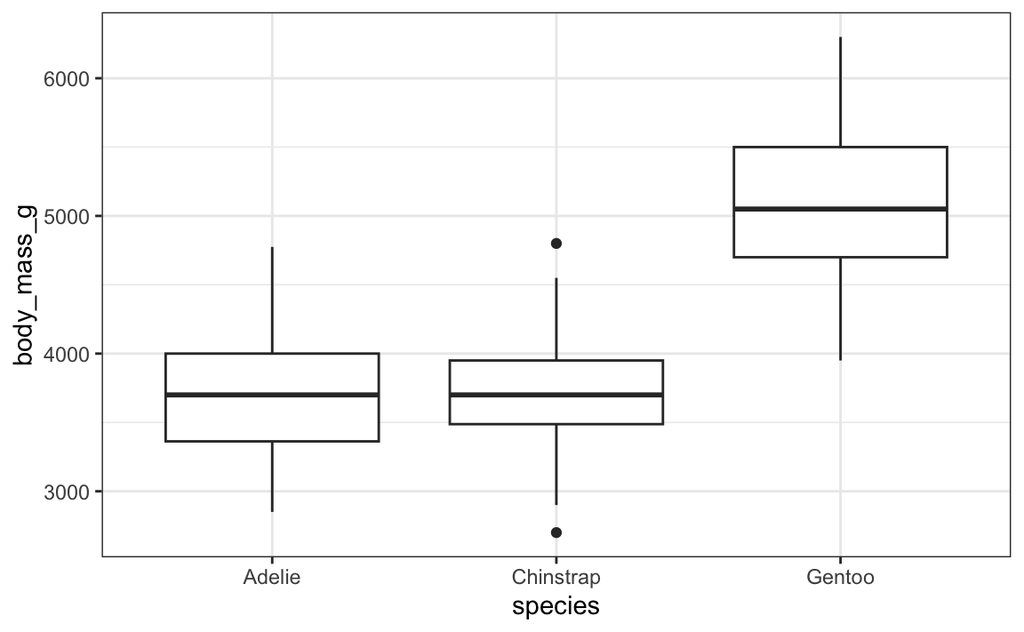

Abbildung 9: `geom_boxplot()`

```r
df_penguins %>%
  ggplot(aes(x = species, y = body_mass_g)) +
  geom_boxplot() +
  theme_bw()
```

- how many/what times types of variable(s) does `geom_boxplot()` take?
  - 2 variables: 1 continuous, 1 categorical

### 4.1.2 Grouped boxplot

- like a bargraph, we can produced grouped boxplots to visualise more variables
  - just map a new variable with `colour` or `fill` aesthetic

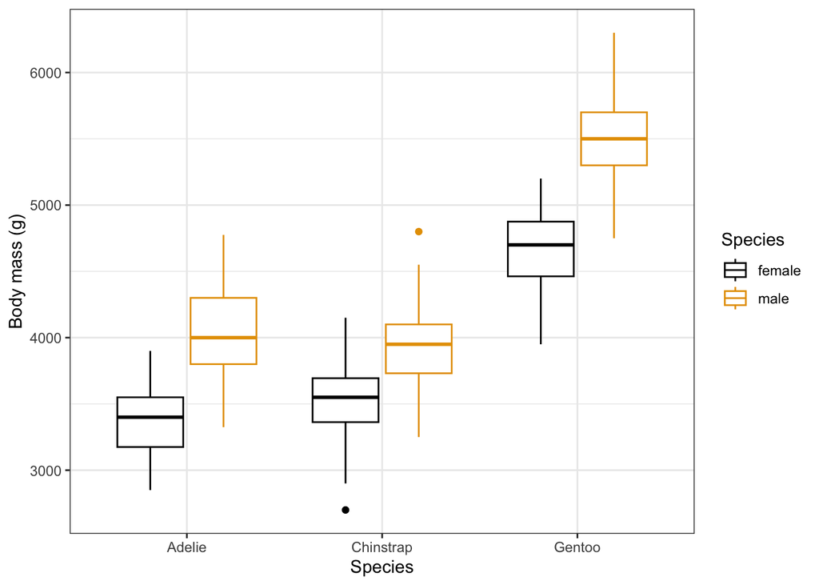

A grouped boxplot

```r
df_penguins %>%
  ggplot(aes(x = species, y = body_mass_g, colour = sex)) +
  geom_boxplot() +
  labs(
    x = "Species",
    y = "Body mass (g)",
    color = "Species",
    shape = "Species"
  ) +
  scale_colour_colorblind() +
  theme_bw()
```

# 5 Visualing the mean

- boxplots show a measure of central tendency, and several measures of dispersion
  - median, IQR (Q1 and Q3), 1.5*IQR (whiskers), and outliers (dots)
- but we typically want to describe the mean and standard deviation when drawing conclusions about differences between groups
- how might we do this?

## 5.1 Errorbar plots

- we can visualise the mean and standard deviation with errorbar plots
  - sometimes called interaction plots
- these plots have 2 parts:
  - the mean, visualised with `geom_point()`
  - the sd, visualised with `geom_errorbar()`
- the errorbars plot the range from 1 standard deviation above and below the mean (mean +/- 1SD)

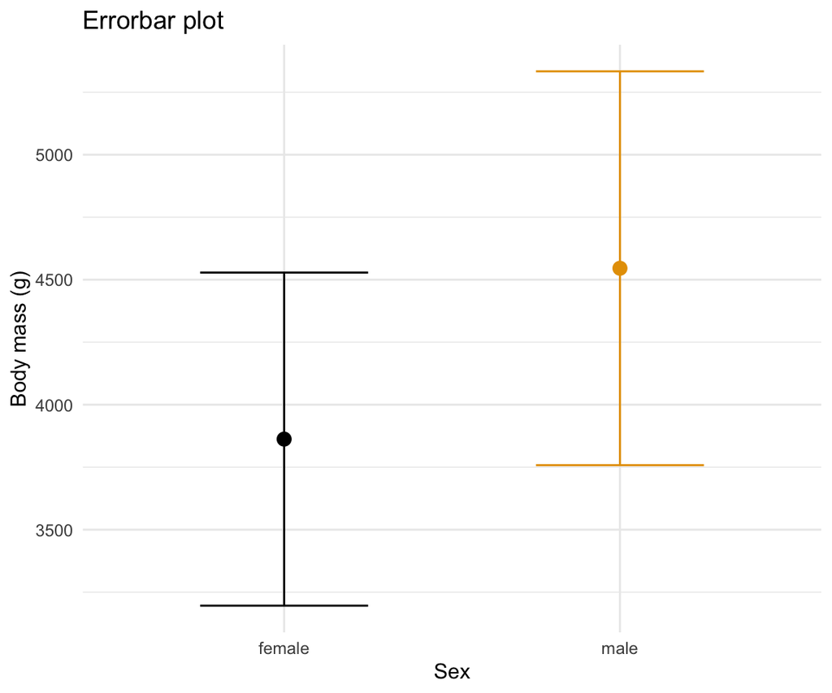

Abbildung 10: Errorbar plot of `df_penguins` (body mass by sex)

#### Computing summary statistics

- we need to first calculate the mean and standard deviation, grouped by whatever variables we want to visualise
  - let’s stick with `body_mass_g` by `species` and `sex`
  - how can we compute the `mean` and `sd` of `body_mass_g` by `species` and `sex`?

```r
df_penguins %>%
  summarise(mean = mean(body_mass_g),
            sd = sd(body_mass_g),
            N = n(),
            .by = c(species,sex)) %>%
  arrange(species, sex) %>%
  knitr::kable() %>%
  kableExtra::kable_styling(font_size = 30)
```

| species | sex | mean | sd | N |
| --- | --- | --- | --- | --- |
| Adelie | female | 3368.836 | 269.3801 | 73 |
| Adelie | male | 4043.493 | 346.8116 | 73 |
| Chinstrap | female | 3527.206 | 285.3339 | 34 |
| Chinstrap | male | 3938.971 | 362.1376 | 34 |
| Gentoo | female | 4679.741 | 281.5783 | 58 |
| Gentoo | male | 5484.836 | 313.1586 | 61 |

- we have to feed this summary into `ggplot2`
  - *without* the table formatting from `knitr` and `kableExtra`!!!!
  - we can do this by saving the summary as a `new object`, or feeding the summary into ggplot directly `with a pipe`

**New object**

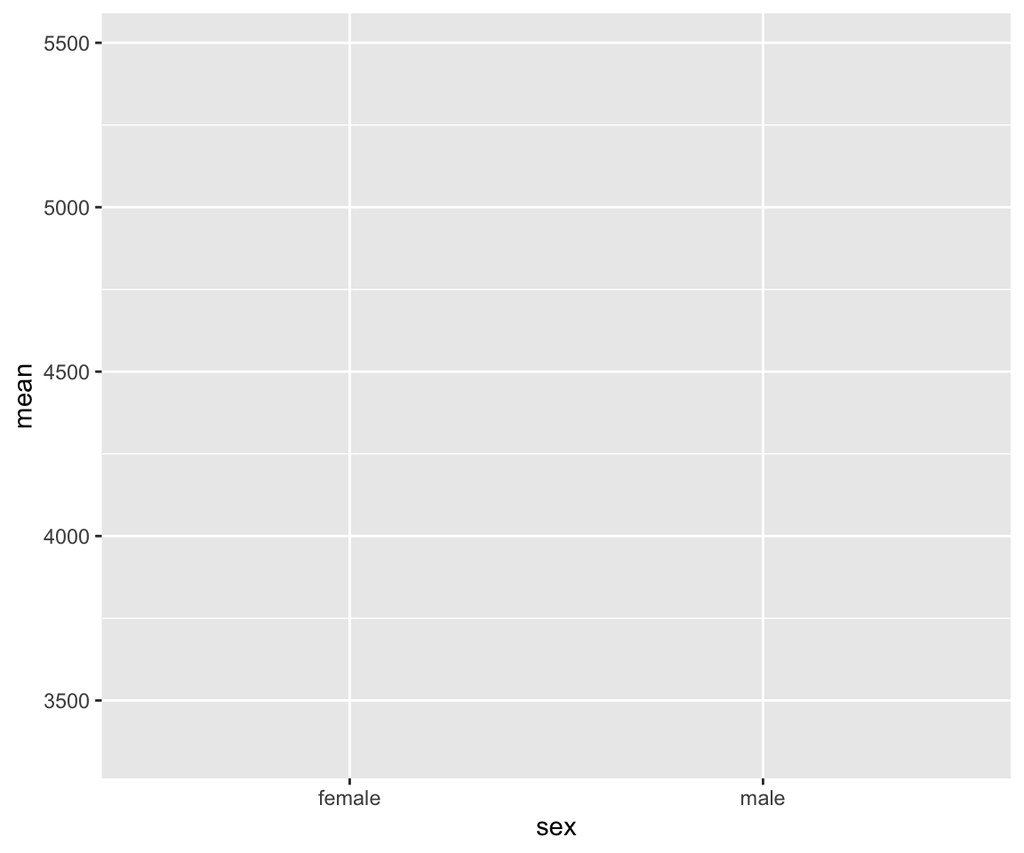

```r
# Create new object with summaries
sum_penguins <- df_penguins %>%
  summarise(mean = mean(body_mass_g),
            sd = sd(body_mass_g),
            upper = mean+sd,
            lower = mean-sd,
            N = n(),
            .by = c(species,sex)) %>%
  arrange(species, sex)
# Feed new object into ggplot
sum_penguins %>%
  ggplot(aes(x = sex, y = mean, colour = species))
```

**With a pipe**

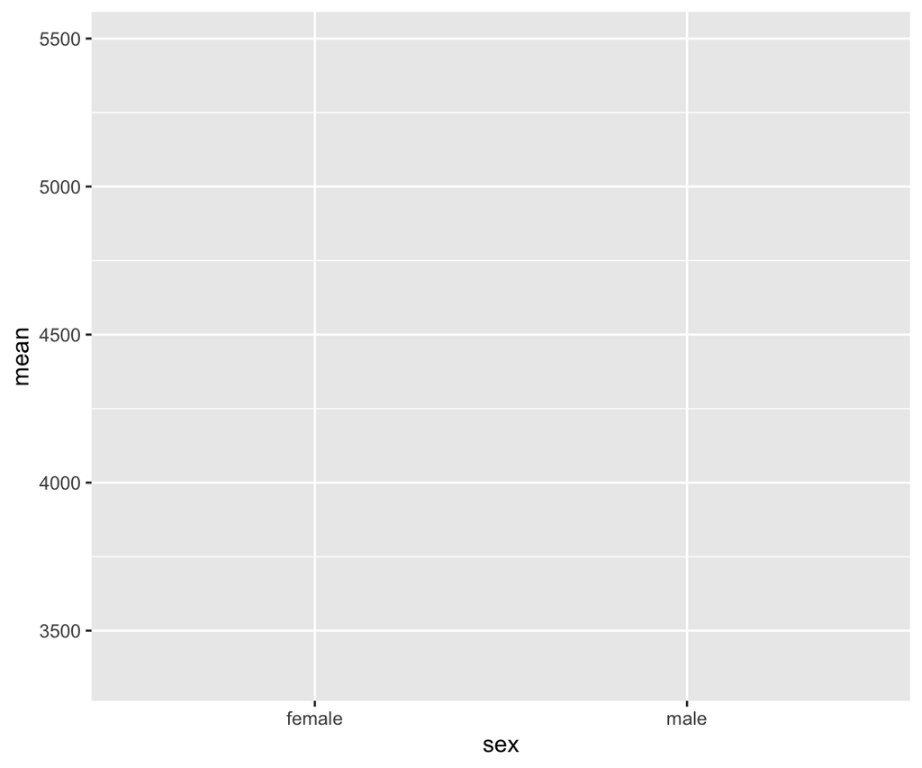

```r
df_penguins %>%
  summarise(mean = mean(body_mass_g),
            sd = sd(body_mass_g),
            upper = mean+sd,
            lower = mean-sd,
            N = n(),
            .by = c(species,sex)) %>%
  arrange(species, sex) %>%
  ggplot(aes(x = sex, y = mean, colour = species))
```

#### Plotting mean

- we do this with `geom_point()`

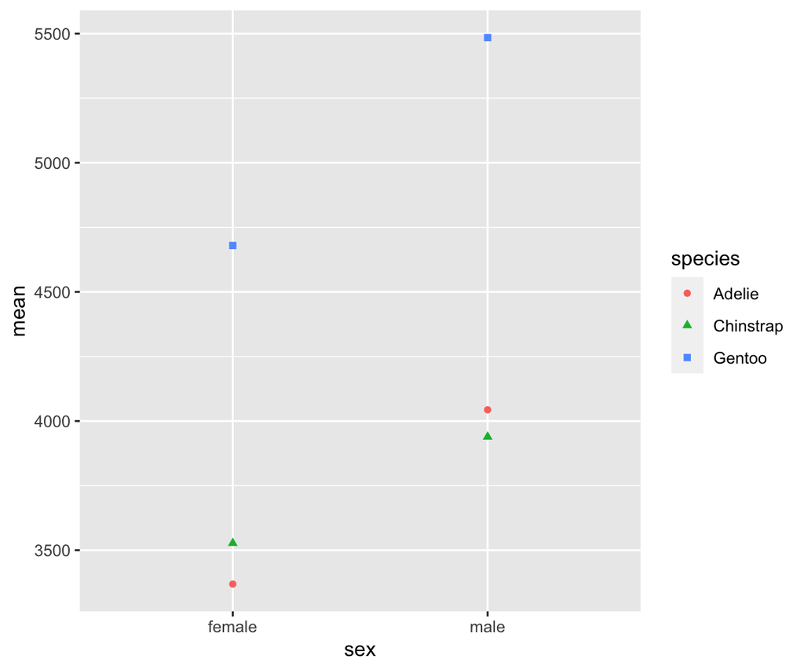

```r
sum_penguins %>%
  ggplot(aes(x = sex, y = mean,
             colour = species, shape = species)) +
  geom_point()
```

#### Adding errorbars

- we do this with `geom_errorbar()`

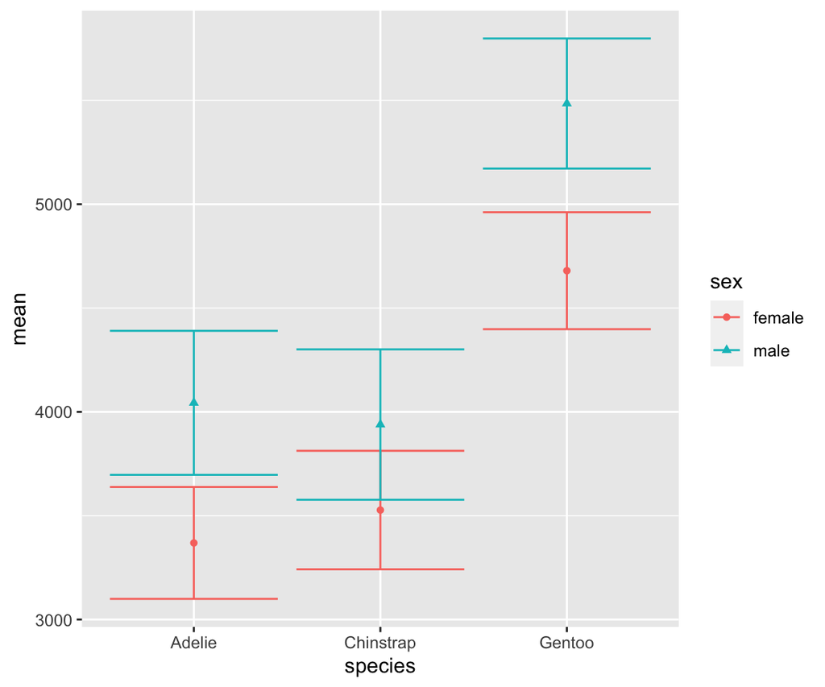

```r
sum_penguins %>%
  ggplot(aes(x = species, y = mean,
             colour = sex, shape = sex)) +
  geom_point() +
  geom_errorbar(aes(ymin=lower,ymax=upper))
```

- we need to add the mapping aesthetics for the upper and lower limits of the errorbar
  - `aes(ymin = mean-sd, ymax = mean+sd)`
  - we used summarise to compute `mean-sd` (`lower`) and `mean+sd` (`upper`) for each group for us, so we can use those instead

**Barplot of mean: stay away!**

Firstly, they can be very misleading. They start at 0 and give the impression that data stop at the mean, when about half the data is (usually) above the mean.

- recall the `datasauRus` package, which contains datasets with similar means, standard deviations, and number of observations
  - but *very* different distributions
- Abbildung 11 shows the distribution of 5 of these datasets (top row), and the mean, sd, and number of observations for the variables `x` and `y`
  - you’ll see that the distributions look very different
- for this reason, it’s a good reason to *always* visualise your raw datapoints regardless of what summary plot you produce (e.g., errorbar plots also hide a lot of data)

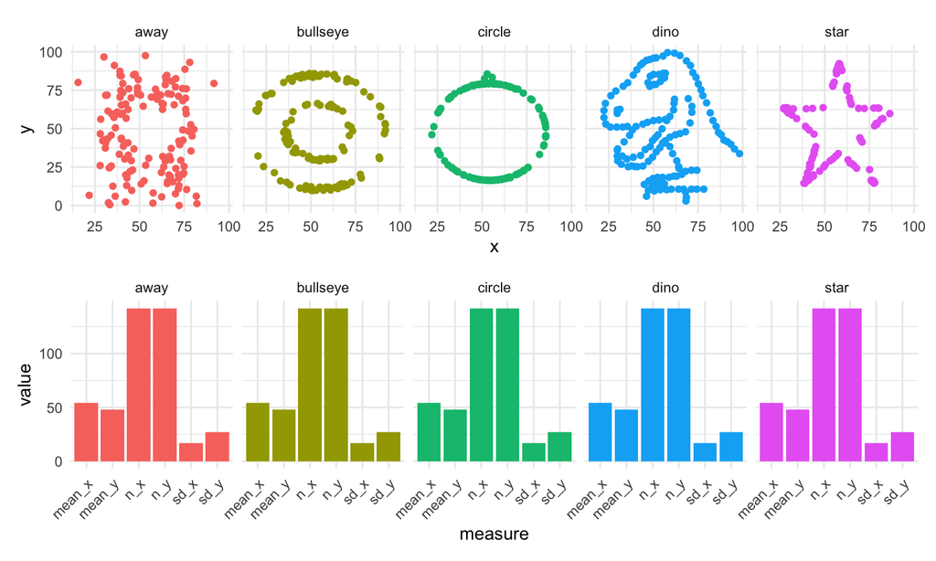

Abbildung 11: Datasets with the same means, sds, and Ns, but very different distributions

### 5.1.1 Customising

- what customisations do you see in the code and plot?

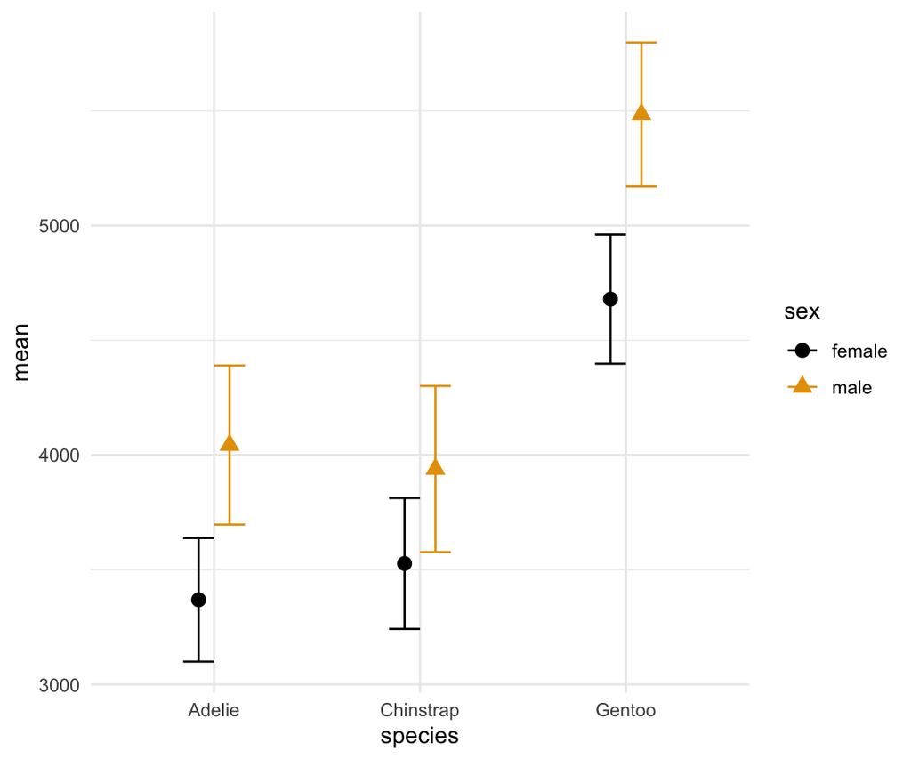

```r
sum_penguins %>%
  ggplot(aes(x = species, y = mean,
             colour = sex, shape = sex)) +
  geom_point(position = position_dodge(0.3),
             size = 3) +
  geom_errorbar(aes(ymin=lower,ymax=upper),
                position = position_dodge(0.3),
                width = .3) +
  scale_colour_colorblind() +
  theme_minimal()
```

- `position = posiiton_dodge(0.3)` tells `ggplot2` how to position objects
  - `position_dodge()` means: move overlapping objects horizontally
  - importantly, you need to use `position_dodge()` for *every* `geom_` that is supposed to be at the same location, and with the same value; otherwise they won’t be aligned
- `geom_point(size = 3)`: adjust the size of the points
- `geom_errorbar(width = .3)`: adjust the width of the errorbars
  - tip: I always give the same value to `position_dodge()` and `geom_errorbar(width = )`, this way the errobars always touch the ‘middle’ line (try changing either value to see what I mean)
- `scale_colour_colorblind()`: use a colorblind-friendly colour scheme
- `theme_minimal()`: cleans up the plot (we’ve also seen `theme_bw()`, more about themes [here](https://ggplot2.tidyverse.org/reference/ggtheme.html))

# 6 Multi-part plots

- we can combine various types of plots to summarise our data but also provide the distribution
  - this is easiest when they use the same underlying data, like violin plots and boxplots

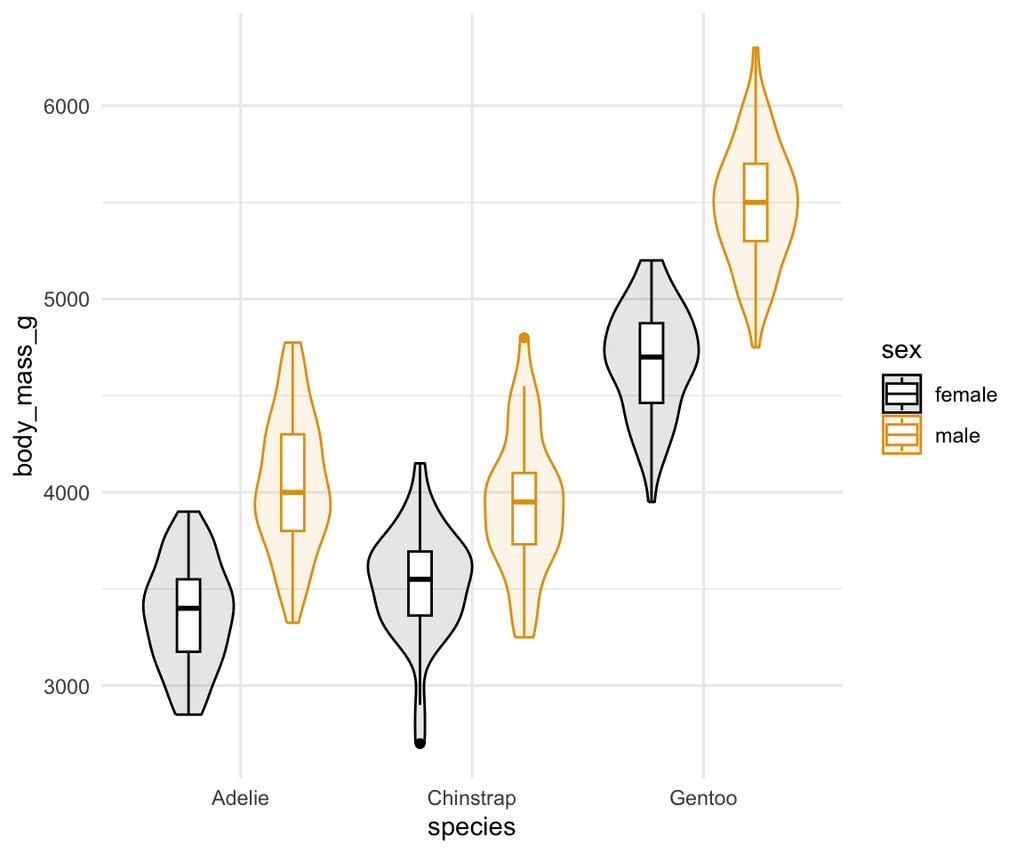

Abbildung 12: A violin-boxplot

```r
df_penguins %>%
  ggplot(aes(x = species, y = body_mass_g,
             colour = sex, shape = sex)) +
  geom_violin(aes(fill = sex), alpha = .1, position = position_dodge(.9)) +
  geom_boxplot(width = .2, position = position_dodge(.9)) +
  scale_colour_colorblind() +
  scale_fill_colorblind() +
  theme_minimal()
```

## 6.1 Plotting different data

- this is trickier when we want to plot summaries (like error bar plots) *and* distributions
  - errorbar plots take data summaries (mean, sd)
  - violin, boxplot, and scatterplots all take the raw data (each row = observation)
- let’s try to add a scatterplot to our errorbar plot
  - this could be done several ways, e.g.,
    - taking a scatter plot and adding the mean and errorbar `geom`s
    - or taking our errorbar plot and adding a scatterplot `geom`
- the latter is a bit simpler, so let’s try that

### 6.1.1 Add scatterplot to errorbar

- use `geom_point()` with the `data` and `aes()` needed

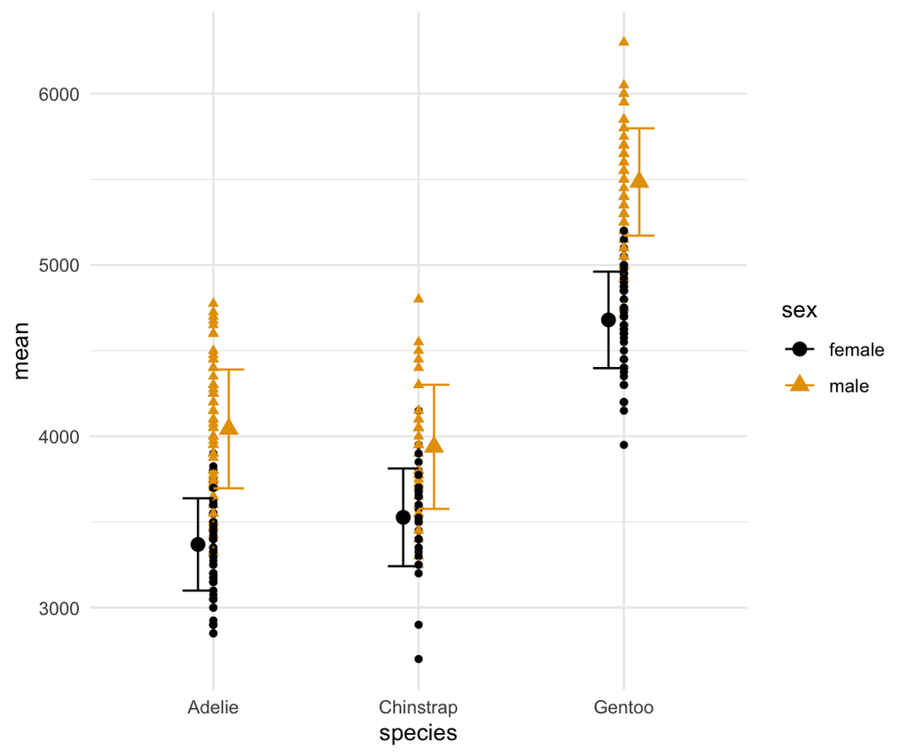

Abbildung 13: Scatterplot with errorbar

```r
sum_penguins %>%
  ggplot(aes(x = species, y = mean,
             colour = sex, shape = sex)) +
  geom_point(data = df_penguins,
             aes(x = species, y = body_mass_g)) +
  geom_point(position = position_dodge(0.3),
             size = 3) +
  geom_errorbar(aes(ymin=lower,ymax=upper),
                position = position_dodge(0.3),
                width = .3) +
  scale_colour_colorblind() +
  theme_minimal()
```

### 6.1.2 Customise scatterplot

- with `position_dodge()`

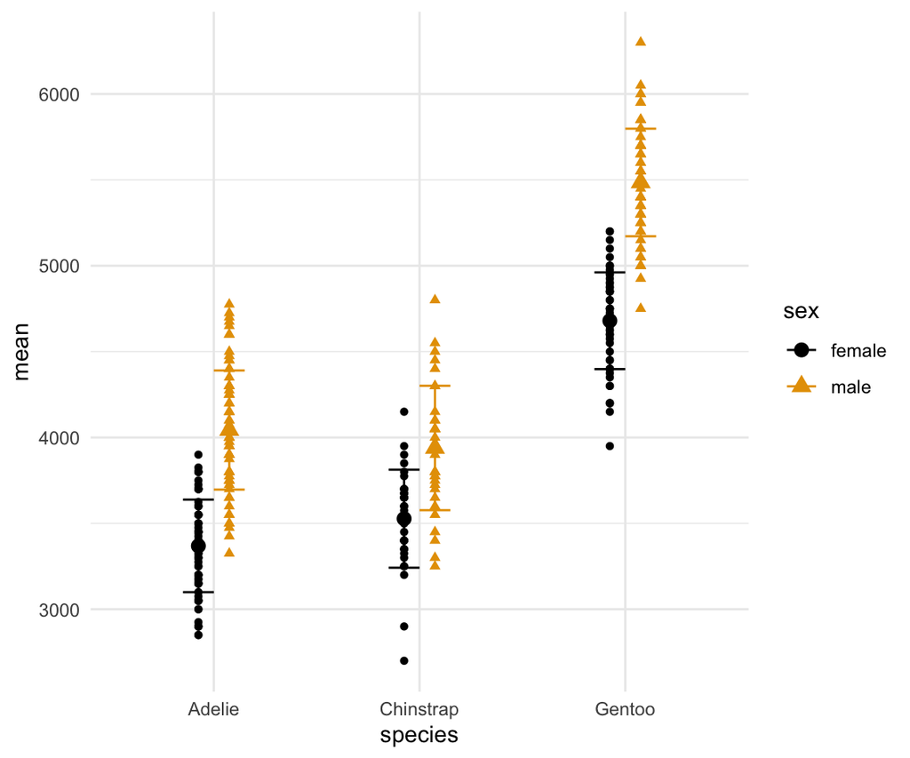

Abbildung 14: Scatterplot with errorbar

```r
sum_penguins %>%
  ggplot(aes(x = species, y = mean,
             colour = sex, shape = sex)) +
  geom_point(data = df_penguins,
             aes(x = species, y = body_mass_g),
             position = position_dodge(0.3)) +
  geom_point(position = position_dodge(0.3),
             size = 3) +
  geom_errorbar(aes(ymin=lower,ymax=upper),
                position = position_dodge(0.3),
                width = .3) +
  scale_colour_colorblind() +
  theme_minimal()
```

### 6.1.3 Add `alpha` value

- so we can distinguish overlapping values

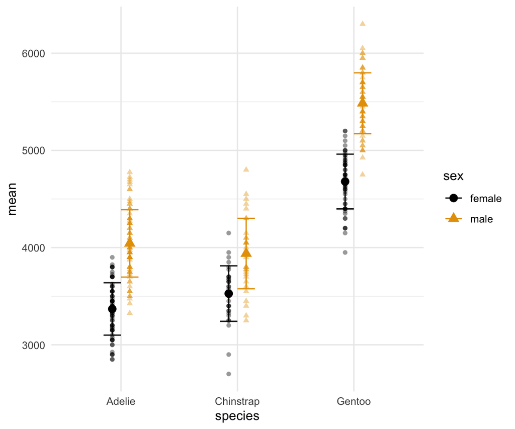

Abbildung 15: Scatterplot with errorbar

```r
sum_penguins %>%
  ggplot(aes(x = species, y = mean,
             colour = sex, shape = sex)) +
  geom_point(data = df_penguins,
             aes(x = species, y = body_mass_g),
             position = position_dodge(0.3),
             alpha = .4) +
  geom_point(position = position_dodge(0.3),
             size = 3) +
  geom_errorbar(aes(ymin=lower,ymax=upper),
                position = position_dodge(0.3),
                width = .3) +
  scale_colour_colorblind() +
  theme_minimal()
```

### 6.1.4 Change position

- `position_jitterdodge()` moves objects to not overlap
  - we can set `dodge.width = .3` to match `position_dodge()` of errorbars
  - and `jitter.width =` to say how much we want the points to jitter
  - and `geom_errorbar(size = 1)` makes the errorbar lines thicker

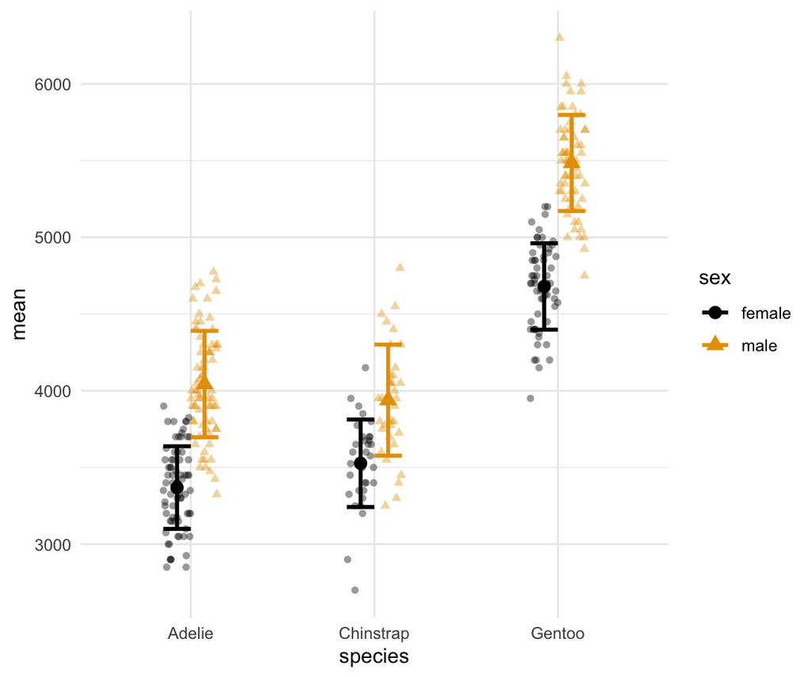

Abbildung 16: Scatterplot with errorbar

```r
sum_penguins %>%
  ggplot(aes(x = species, y = mean,
             colour = sex, shape = sex)) +
  geom_point(data = df_penguins,
             aes(y = body_mass_g),
             position = position_jitterdodge(dodge.width = .3,
                                  jitter.width = 0.3),
             alpha = .4) +
  geom_point(position = position_dodge(width =0.3),
             size = 3) +
  geom_errorbar(aes(ymin=lower,ymax=upper),
                position = position_dodge(0.3),
                width = .3,
                size = 1) +
  scale_colour_colorblind() +
  theme_minimal()
```

# Heutige Ziele 🏁

Heute haben wir gelernt, wie man…

- use `facet_wrap()` to plot more than three variables ✅
- visualise summary statistics ✅
- create multi-part plots ✅

# 7 Aufgaben

## 7.1 Boxplot with facet

1. Produce a boxplot of the `df_penguins` data, with:
   - `sex` plotted on the `x` axis and with `colour` *or* `fill` (choose one)
   - `flipper_length_mm` plotted along the `y` axis
   - `island` plotted in three panels using `facet_wrap()`
   - whichever `theme_` setting you choose (e.g., `theme_bw()`; for more options see [here](https://ggplot2.tidyverse.org/reference/ggtheme.html))

## 7.2 Code chunk options

2. Add a `label` to the figure (`fig-...`) and a caption (`fig-cap:`). Briefly describe the plot, using a cross-reference (*`@fig-...` shows that…*).

## 7.3 Multi-layered plot

3. Try to reproduce Abbildung 17. Hint: You will need to add one `geom_` and some labels to Abbildung 12.

[figure not shown]

Abbildung 17: A multi-layered plot

## 7.4 Patchwork

4. Using the `patchwork` package (see week 3 notes), plot your boxplot and your errorbar/violin plots side by side. It should look something like Abbildung 18.
   - hint: if you want to add the “tag levels” (“A” and “B”), you need to add `+ plot_annotation(tag_level = "A")` from `patchwork`

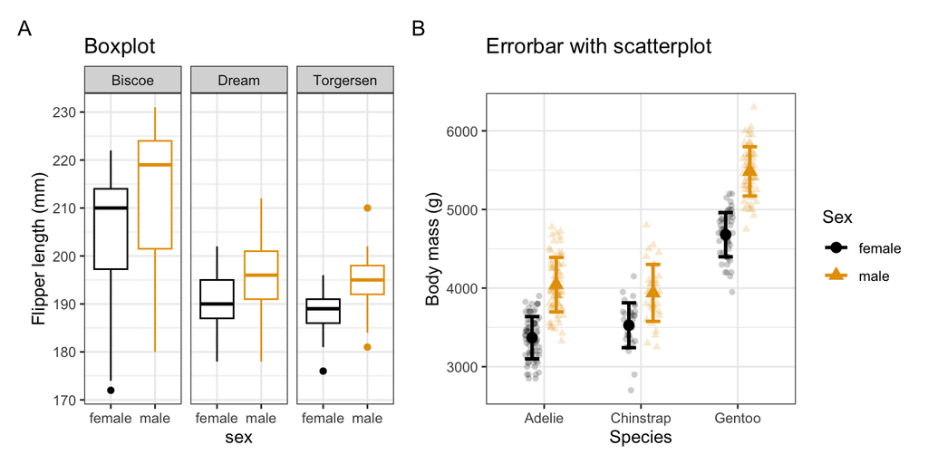

Abbildung 18: Combined plots with `patchwork`

# Session Info

Hergestellt mit R version 4.3.0 (2023-04-21) (Already Tomorrow) und RStudioversion 2023.3.0.386 (Cherry Blossom).

# Literaturverzeichnis

Nordmann, E., McAleer, P., Toivo, W., Paterson, H., & DeBruine, L. M. (2022). Data Visualization Using R for Researchers Who Do Not Use R. *Advances in Methods and Practices in Psychological Science*, *5*(2), 251524592210746. https://doi.org/10.1177/25152459221074654

Wickham, H., Çetinkaya-Rundel, M., & Grolemund, G. (o. J.). *R for Data Science* (2. Aufl.). https://r4ds.hadley.nz/